# How to Explain in CIS241

This file includes code and examples for explaining graphs and statistical output in DA101. Communicating results is a crucial part of good data analysis, and we try to communicate all results *completely and accurately and in terms of the data*.

These short examples are designed to give you general guidance. I cannot provide a comprehensive example or answer that you could “copy” every time to have an A+ explanation, but I can provide an example and some pointers to help you get started.

(This is adapted from "[How to explain in DA101](https://jrladd.com/DA101/resources/how-to-explain)".)

## How to Explain a Visualization

The way you explain your graphs will change throughout the semester as you learn more details about what the graph shows and also learn more technical lingo for how to identify different aspects of the graph, including visual interpretation of summary statistics, and how to identify potentially significant differences or outliers.

In the beginning of class (let’s say weeks 1-2) I won’t assume you have prior technical knowledge of data analysis, and it is okay to stick to general descriptive and observational descriptions of what you’re seeing in a graph that you make. What are you noticing? What stands out to you? Do you see anything that looks like a pattern in the points or that indicates similarity among groups?

### Graph 1: Explaining a Boxplot

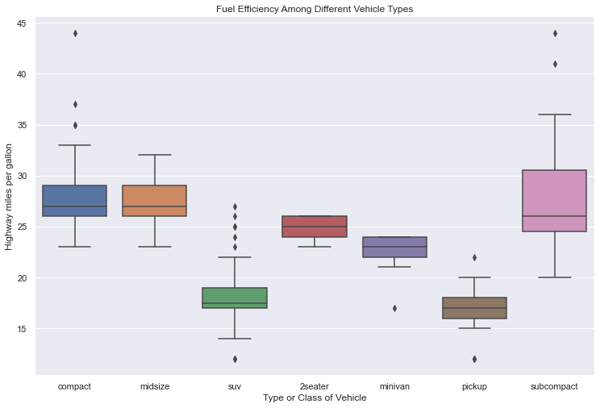

#### Basic Explanation (Weeks 1-2)

This boxplot of the `mpg` data set shows the distributions of highway fuel efficiency across the seven different kinds of cars in the data. Pickups and SUVs seem to have lower fuel efficiency than the other cars, which makes sense because they are bigger, heavier vehicles. Smaller vehicles like compact and midsize cars have greater fuel efficiency, and subcompacts have similarly high fuel efficiency but the data seems to be more spread out because the box is longer. Overall it seems like vehicle class is related to fuel efficiency, with smaller cars tending to have greater efficiency.

#### Detailed Explanation (Weeks 3+)

This boxplot of the `mpg` data set shows the distributions of highway fuel efficiency across the seven different kinds of cars in the data. Pickups and SUVs have medians and interquartile ranges well below the other vehicles, suggesting a statistically significant difference. Compact cars have a nearly identical IQR and median to midsize cars, as evidenced by the size of the two boxes, though there are a handful of outliers in the compact group. Subcompacts have a larger interquartile range than any of the other groups, which suggests greater variability in their fuel efficiency distribution. Overall the graph suggests that larger vehicle classes tend to have lower fuel efficiency distributions, while smaller vehicles seem to have greater fuel efficiency.

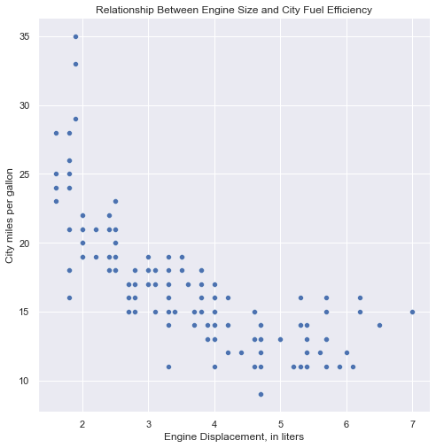

#### Basic Explanation (Weeks 1-2)

This scatter plot of the `mpg` data set shows the relationship between the size of a car’s engine (using the engine displacement variable) and a car’s city fuel efficiency. Because of the downward slope of the dots as the graph goes from left to right, it appears that as engines get bigger the city fuel efficiency gets smaller. After about 4.5 liters the slope levels off, suggesting there isn’t as strong a relationship past this point. Overall, we could conclude that a car’s city fuel efficiency may partially depend on the size of the engine.

#### Detailed Explanation (Weeks 3+)

This scatter plot of the `mpg` data set shows the relationship between the size of a car’s engine (using the engine displacement variable) and a car’s city fuel efficiency. There looks to be a negative correlation between the two variables: as engine displacement goes up, city miles per gallon goes down. Adding a line of best fit to this graph or calculating a correlation coefficient would give us a better indication of the possible correlation. After about 4.5 liters, the points no longer slope downward, which may indicate that after a certain threshold, engine displacement has no direct correlation to fuel efficiency. Overall we could conclude that our dependent variable, city miles per gallon, negatively correlates with our independent variable, engine displacement, and therefore that as engine size gets larger fuel efficiency drops.

## How to explain statistical output

We will learn several statistical tests and models throughout the semester. In data analysis, there is much more to do than to simply write the code for the model and generate “correct” output or report a p-value. In most cases, explaining the output and validation from the models will require several sentences that help to translate the quantitative results in terms of the data. In general, when running these models and interpreting output, there are a few key things to keep in mind.

1. **Do you have a logical reason for running the test or model**?
2. After you’ve run the code, were you able to **calculate and report the key values** from the statistical output?
3. After you have identified and reported the key values, can you **connect them back to the data and the question at hand**?
4. Finally, can you **describe the results in terms of statistical *and practical* significance**?

### Statistical Example 1: Explaining a permutation test for comparing means

```
Mean mpg of compact: 28.30
Mean mpg of midsize: 27.29
Difference in means of compact and midsize cars: 1.005 miles per gallon
```

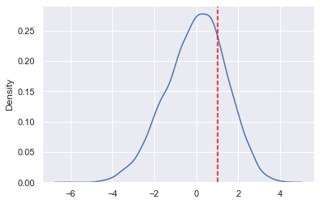

```
p-value = 0.2385
```

### Statistical Example 2: Explaining a Linear Regression

```
Intercept: 25.362
Coefficient (Slope): -2.4581
```

```
Root mean squared error: 2.27
Coefficient of determination (R-squared): 0.67
```

This linear regression model looks at the effect engine displacement in liters has on city miles per gallon fuel efficiency. It suggests a negative relationship: for each liter of engine displacement, city miles per gallon decreases by 2.46. $R^2$ is .67, suggesting that 67% of the variation in city fuel efficiency is accounted for by engine displacement. I am unsure that this result is practically signficant. For a mechanical process like the fuel efficiency of an engine, we might expect to see an $R^2$ higher than 67%. The variance of the data as `cty` goes up might be part of the reason for this (see the scatter plot with regression line, below). The root mean squared error is 2.27, meaning that the residuals are off on average by more than 2 miles per gallon. This seems like a fair amount and raises some questions about the accuracy of the model.

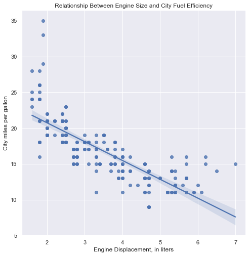